# Risk Factor Analysis

## Outcome Variable

**Outcome Variable:** whz

## Predictor Variables

**Intervention Variable:** nhh

**Adjustment Set:**

unadjusted

## Stratifying Variables

The analysis was stratified on these variable(s):

- agecat
- studyid
- country

## Data Summary

| agecat | studyid | country | nhh | n_cell | n |
| --- | --- | --- | --- | --- | --- |
| Birth | ki1000108-IRC | INDIA | 3 or less | 52 | 343 |
| Birth | ki1000108-IRC | INDIA | 4-5 | 131 | 343 |
| Birth | ki1000108-IRC | INDIA | 6-7 | 84 | 343 |
| Birth | ki1000108-IRC | INDIA | 8+ | 76 | 343 |
| Birth | ki1017093-NIH-Birth | BANGLADESH | 3 or less | 7 | 28 |
| Birth | ki1017093-NIH-Birth | BANGLADESH | 4-5 | 11 | 28 |
| Birth | ki1017093-NIH-Birth | BANGLADESH | 6-7 | 7 | 28 |
| Birth | ki1017093-NIH-Birth | BANGLADESH | 8+ | 3 | 28 |
| Birth | ki1017093c-NIH-Crypto | BANGLADESH | 3 or less | 8 | 23 |
| Birth | ki1017093c-NIH-Crypto | BANGLADESH | 4-5 | 7 | 23 |
| Birth | ki1017093c-NIH-Crypto | BANGLADESH | 6-7 | 5 | 23 |
| Birth | ki1017093c-NIH-Crypto | BANGLADESH | 8+ | 3 | 23 |
| 6 months | ki1000108-IRC | INDIA | 3 or less | 57 | 408 |
| 6 months | ki1000108-IRC | INDIA | 4-5 | 157 | 408 |
| 6 months | ki1000108-IRC | INDIA | 6-7 | 107 | 408 |
| 6 months | ki1000108-IRC | INDIA | 8+ | 87 | 408 |
| 6 months | ki1000304b-SAS-FoodSuppl | INDIA | 3 or less | 33 | 380 |
| 6 months | ki1000304b-SAS-FoodSuppl | INDIA | 4-5 | 166 | 380 |
| 6 months | ki1000304b-SAS-FoodSuppl | INDIA | 6-7 | 115 | 380 |
| 6 months | ki1000304b-SAS-FoodSuppl | INDIA | 8+ | 66 | 380 |
| 6 months | ki1017093-NIH-Birth | BANGLADESH | 3 or less | 95 | 536 |
| 6 months | ki1017093-NIH-Birth | BANGLADESH | 4-5 | 227 | 536 |
| 6 months | ki1017093-NIH-Birth | BANGLADESH | 6-7 | 127 | 536 |
| 6 months | ki1017093-NIH-Birth | BANGLADESH | 8+ | 87 | 536 |
| 6 months | ki1017093b-PROVIDE | BANGLADESH | 3 or less | 102 | 582 |
| 6 months | ki1017093b-PROVIDE | BANGLADESH | 4-5 | 277 | 582 |
| 6 months | ki1017093b-PROVIDE | BANGLADESH | 6-7 | 126 | 582 |
| 6 months | ki1017093b-PROVIDE | BANGLADESH | 8+ | 77 | 582 |
| 6 months | ki1017093c-NIH-Crypto | BANGLADESH | 3 or less | 104 | 715 |
| 6 months | ki1017093c-NIH-Crypto | BANGLADESH | 4-5 | 326 | 715 |
| 6 months | ki1017093c-NIH-Crypto | BANGLADESH | 6-7 | 170 | 715 |
| 6 months | ki1017093c-NIH-Crypto | BANGLADESH | 8+ | 115 | 715 |
| 6 months | ki1148112-LCNI-5 | MALAWI | 3 or less | 224 | 816 |
| 6 months | ki1148112-LCNI-5 | MALAWI | 4-5 | 340 | 816 |
| 6 months | ki1148112-LCNI-5 | MALAWI | 6-7 | 182 | 816 |
| 6 months | ki1148112-LCNI-5 | MALAWI | 8+ | 70 | 816 |
| 24 months | ki1000108-IRC | INDIA | 3 or less | 58 | 409 |
| 24 months | ki1000108-IRC | INDIA | 4-5 | 158 | 409 |
| 24 months | ki1000108-IRC | INDIA | 6-7 | 107 | 409 |
| 24 months | ki1000108-IRC | INDIA | 8+ | 86 | 409 |
| 24 months | ki1017093-NIH-Birth | BANGLADESH | 3 or less | 74 | 428 |
| 24 months | ki1017093-NIH-Birth | BANGLADESH | 4-5 | 184 | 428 |
| 24 months | ki1017093-NIH-Birth | BANGLADESH | 6-7 | 100 | 428 |
| 24 months | ki1017093-NIH-Birth | BANGLADESH | 8+ | 70 | 428 |
| 24 months | ki1017093b-PROVIDE | BANGLADESH | 3 or less | 105 | 578 |
| 24 months | ki1017093b-PROVIDE | BANGLADESH | 4-5 | 273 | 578 |
| 24 months | ki1017093b-PROVIDE | BANGLADESH | 6-7 | 117 | 578 |
| 24 months | ki1017093b-PROVIDE | BANGLADESH | 8+ | 83 | 578 |
| 24 months | ki1017093c-NIH-Crypto | BANGLADESH | 3 or less | 69 | 514 |
| 24 months | ki1017093c-NIH-Crypto | BANGLADESH | 4-5 | 232 | 514 |
| 24 months | ki1017093c-NIH-Crypto | BANGLADESH | 6-7 | 130 | 514 |
| 24 months | ki1017093c-NIH-Crypto | BANGLADESH | 8+ | 83 | 514 |
| 24 months | ki1148112-LCNI-5 | MALAWI | 3 or less | 157 | 558 |
| 24 months | ki1148112-LCNI-5 | MALAWI | 4-5 | 230 | 558 |
| 24 months | ki1148112-LCNI-5 | MALAWI | 6-7 | 123 | 558 |
| 24 months | ki1148112-LCNI-5 | MALAWI | 8+ | 48 | 558 |

The following strata were considered:

- agecat: 24 months, studyid: ki1000108-IRC, country: INDIA
- agecat: 24 months, studyid: ki1017093-NIH-Birth, country: BANGLADESH
- agecat: 24 months, studyid: ki1017093b-PROVIDE, country: BANGLADESH
- agecat: 24 months, studyid: ki1017093c-NIH-Crypto, country: BANGLADESH
- agecat: 24 months, studyid: ki1148112-LCNI-5, country: MALAWI
- agecat: 6 months, studyid: ki1000108-IRC, country: INDIA
- agecat: 6 months, studyid: ki1000304b-SAS-FoodSuppl, country: INDIA
- agecat: 6 months, studyid: ki1017093-NIH-Birth, country: BANGLADESH
- agecat: 6 months, studyid: ki1017093b-PROVIDE, country: BANGLADESH
- agecat: 6 months, studyid: ki1017093c-NIH-Crypto, country: BANGLADESH
- agecat: 6 months, studyid: ki1148112-LCNI-5, country: MALAWI
- agecat: Birth, studyid: ki1000108-IRC, country: INDIA
- agecat: Birth, studyid: ki1017093-NIH-Birth, country: BANGLADESH
- agecat: Birth, studyid: ki1017093c-NIH-Crypto, country: BANGLADESH

### Dropped Strata

Some strata were dropped due to rare outcomes:

- agecat: Birth, studyid: ki1017093-NIH-Birth, country: BANGLADESH
- agecat: Birth, studyid: ki1017093c-NIH-Crypto, country: BANGLADESH

## Methods Detail

We’re interested in the causal parameters $E[Y_a]$ for all values of $a \in \mathcal{A}$. These parameters represent the mean outcome if, possibly contrary to fact, we intervened to set all units to have $A=a$. Under the randomization and positivity assumptions, these are identified by the statistical parameters $\psi_a=E_W[E_{Y|A,W}(Y|A=a,W)]$. In addition, we’re interested in the mean of $Y$, $E[Y]$ under no intervention (the observed mean). We will estimate these parameters by using SuperLearner to fit the relevant likelihood factors – $E_{Y|A,W}(Y|A=a,W)$ and $p(A=a|W)$, and then updating our likelihood fit using a joint TMLE.

For unadjusted analyses ($W=\{\}$), initial likelihoods were estimated using Lrnr_glm to estimate the simple $E(Y|A)$ and Lrnr_mean to estimate $p(A)$. For adjusted analyses, a small library containing Lrnr_glmnet, Lrnr_xgboost, and Lrnr_mean was used.

Having estimated these parameters, we will then use the delta method to estimate relative risks and attributable risks relative to a prespecified baseline level of $A$.

# Results Detail

## Results Plots

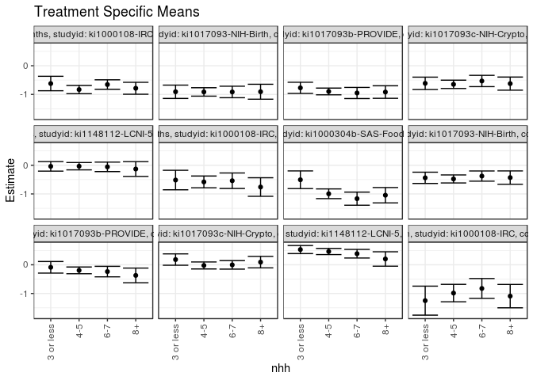

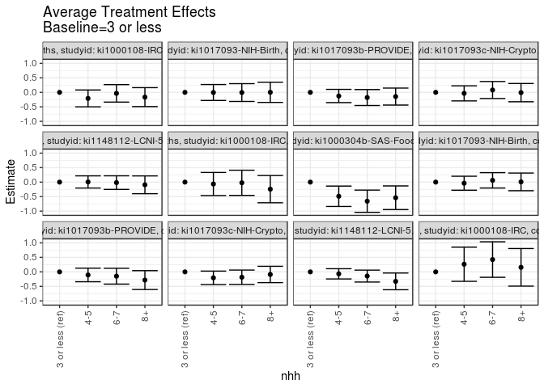

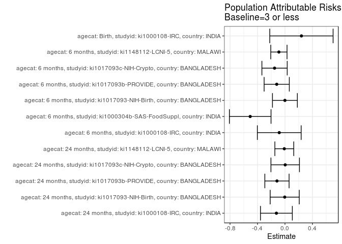

## Results Table

### Parameter: TSM

| agecat | studyid | country | intervention_level | baseline_level | estimate | ci_lower | ci_upper |
| --- | --- | --- | --- | --- | --- | --- | --- |
| Birth | ki1000108-IRC | INDIA | 3 or less | NA | -1.2501923 | -1.7553866 | -0.7449980 |
| Birth | ki1000108-IRC | INDIA | 4-5 | NA | -0.9866412 | -1.2906453 | -0.6826371 |
| Birth | ki1000108-IRC | INDIA | 6-7 | NA | -0.8254762 | -1.1713949 | -0.4795575 |
| Birth | ki1000108-IRC | INDIA | 8+ | NA | -1.0925000 | -1.4994234 | -0.6855766 |
| 6 months | ki1000108-IRC | INDIA | 3 or less | NA | -0.5154386 | -0.8555810 | -0.1752962 |
| 6 months | ki1000108-IRC | INDIA | 4-5 | NA | -0.5811677 | -0.7868221 | -0.3755133 |
| 6 months | ki1000108-IRC | INDIA | 6-7 | NA | -0.5393769 | -0.8095791 | -0.2691748 |
| 6 months | ki1000108-IRC | INDIA | 8+ | NA | -0.7589272 | -1.0822316 | -0.4356228 |
| 6 months | ki1000304b-SAS-FoodSuppl | INDIA | 3 or less | NA | -0.5057576 | -0.8139467 | -0.1975684 |
| 6 months | ki1000304b-SAS-FoodSuppl | INDIA | 4-5 | NA | -0.9942169 | -1.1635351 | -0.8248986 |
| 6 months | ki1000304b-SAS-FoodSuppl | INDIA | 6-7 | NA | -1.1646087 | -1.3932289 | -0.9359885 |
| 6 months | ki1000304b-SAS-FoodSuppl | INDIA | 8+ | NA | -1.0448485 | -1.3121213 | -0.7775757 |
| 6 months | ki1017093-NIH-Birth | BANGLADESH | 3 or less | NA | -0.4380702 | -0.6344243 | -0.2417160 |
| 6 months | ki1017093-NIH-Birth | BANGLADESH | 4-5 | NA | -0.4771769 | -0.6170734 | -0.3372804 |
| 6 months | ki1017093-NIH-Birth | BANGLADESH | 6-7 | NA | -0.3770144 | -0.5544094 | -0.1996195 |
| 6 months | ki1017093-NIH-Birth | BANGLADESH | 8+ | NA | -0.4303352 | -0.6631297 | -0.1975408 |
| 6 months | ki1017093b-PROVIDE | BANGLADESH | 3 or less | NA | -0.0881373 | -0.2901132 | 0.1138386 |
| 6 months | ki1017093b-PROVIDE | BANGLADESH | 4-5 | NA | -0.1943863 | -0.3115068 | -0.0772657 |
| 6 months | ki1017093b-PROVIDE | BANGLADESH | 6-7 | NA | -0.2371164 | -0.4209141 | -0.0533187 |
| 6 months | ki1017093b-PROVIDE | BANGLADESH | 8+ | NA | -0.3709091 | -0.6264376 | -0.1153806 |
| 6 months | ki1017093c-NIH-Crypto | BANGLADESH | 3 or less | NA | 0.1815385 | -0.0163587 | 0.3794357 |
| 6 months | ki1017093c-NIH-Crypto | BANGLADESH | 4-5 | NA | -0.0237577 | -0.1456473 | 0.0981320 |
| 6 months | ki1017093c-NIH-Crypto | BANGLADESH | 6-7 | NA | -0.0028824 | -0.1508866 | 0.1451219 |
| 6 months | ki1017093c-NIH-Crypto | BANGLADESH | 8+ | NA | 0.0924783 | -0.1084867 | 0.2934432 |
| 6 months | ki1148112-LCNI-5 | MALAWI | 3 or less | NA | 0.5304464 | 0.3897965 | 0.6710963 |
| 6 months | ki1148112-LCNI-5 | MALAWI | 4-5 | NA | 0.4627059 | 0.3552092 | 0.5702026 |
| 6 months | ki1148112-LCNI-5 | MALAWI | 6-7 | NA | 0.3857143 | 0.2360212 | 0.5354073 |
| 6 months | ki1148112-LCNI-5 | MALAWI | 8+ | NA | 0.2025714 | -0.0484502 | 0.4535931 |
| 24 months | ki1000108-IRC | INDIA | 3 or less | NA | -0.6209770 | -0.8730190 | -0.3689350 |
| 24 months | ki1000108-IRC | INDIA | 4-5 | NA | -0.8305802 | -0.9756749 | -0.6854855 |
| 24 months | ki1000108-IRC | INDIA | 6-7 | NA | -0.6561682 | -0.8217662 | -0.4905702 |
| 24 months | ki1000108-IRC | INDIA | 8+ | NA | -0.7858140 | -0.9939620 | -0.5776660 |
| 24 months | ki1017093-NIH-Birth | BANGLADESH | 3 or less | NA | -0.9077477 | -1.1399785 | -0.6755170 |
| 24 months | ki1017093-NIH-Birth | BANGLADESH | 4-5 | NA | -0.9133243 | -1.0599469 | -0.7667017 |
| 24 months | ki1017093-NIH-Birth | BANGLADESH | 6-7 | NA | -0.9146917 | -1.1151591 | -0.7142242 |
| 24 months | ki1017093-NIH-Birth | BANGLADESH | 8+ | NA | -0.9065952 | -1.1666898 | -0.6465007 |
| 24 months | ki1017093b-PROVIDE | BANGLADESH | 3 or less | NA | -0.7712381 | -0.9665883 | -0.5758879 |
| 24 months | ki1017093b-PROVIDE | BANGLADESH | 4-5 | NA | -0.8972161 | -1.0146305 | -0.7798017 |
| 24 months | ki1017093b-PROVIDE | BANGLADESH | 6-7 | NA | -0.9501709 | -1.1435776 | -0.7567643 |
| 24 months | ki1017093b-PROVIDE | BANGLADESH | 8+ | NA | -0.9173494 | -1.1360763 | -0.6986225 |
| 24 months | ki1017093c-NIH-Crypto | BANGLADESH | 3 or less | NA | -0.6136232 | -0.8297405 | -0.3975059 |
| 24 months | ki1017093c-NIH-Crypto | BANGLADESH | 4-5 | NA | -0.6484483 | -0.7929739 | -0.5039227 |
| 24 months | ki1017093c-NIH-Crypto | BANGLADESH | 6-7 | NA | -0.5323077 | -0.7295402 | -0.3350752 |
| 24 months | ki1017093c-NIH-Crypto | BANGLADESH | 8+ | NA | -0.6233735 | -0.8517043 | -0.3950427 |
| 24 months | ki1148112-LCNI-5 | MALAWI | 3 or less | NA | -0.0380892 | -0.2047858 | 0.1286074 |
| 24 months | ki1148112-LCNI-5 | MALAWI | 4-5 | NA | -0.0329565 | -0.1604411 | 0.0945281 |
| 24 months | ki1148112-LCNI-5 | MALAWI | 6-7 | NA | -0.0556911 | -0.2204413 | 0.1090592 |
| 24 months | ki1148112-LCNI-5 | MALAWI | 8+ | NA | -0.1312500 | -0.3891485 | 0.1266485 |

### Parameter: E(Y)

| agecat | studyid | country | intervention_level | baseline_level | estimate | ci_lower | ci_upper |
| --- | --- | --- | --- | --- | --- | --- | --- |
| Birth | ki1000108-IRC | INDIA | NA | NA | -1.0105831 | -1.1973019 | -0.8238643 |
| 6 months | ki1000108-IRC | INDIA | NA | NA | -0.5989297 | -0.7344491 | -0.4634104 |
| 6 months | ki1000304b-SAS-FoodSuppl | INDIA | NA | NA | -1.0121579 | -1.1280429 | -0.8962729 |
| 6 months | ki1017093-NIH-Birth | BANGLADESH | NA | NA | -0.4389101 | -0.5279432 | -0.3498771 |
| 6 months | ki1017093b-PROVIDE | BANGLADESH | NA | NA | -0.2083706 | -0.2927992 | -0.1239419 |
| 6 months | ki1017093c-NIH-Crypto | BANGLADESH | NA | NA | 0.0297622 | -0.0491685 | 0.1086930 |
| 6 months | ki1148112-LCNI-5 | MALAWI | NA | NA | 0.4418137 | 0.3703100 | 0.5133174 |
| 24 months | ki1000108-IRC | INDIA | NA | NA | -0.7458150 | -0.8368180 | -0.6548120 |
| 24 months | ki1017093-NIH-Birth | BANGLADESH | NA | NA | -0.9115790 | -1.0095022 | -0.8136559 |
| 24 months | ki1017093b-PROVIDE | BANGLADESH | NA | NA | -0.8879412 | -0.9708680 | -0.8050144 |
| 24 months | ki1017093c-NIH-Crypto | BANGLADESH | NA | NA | -0.6103502 | -0.7050157 | -0.5156847 |
| 24 months | ki1148112-LCNI-5 | MALAWI | NA | NA | -0.0478674 | -0.1301904 | 0.0344557 |

### Parameter: ATE

| agecat | studyid | country | intervention_level | baseline_level | estimate | ci_lower | ci_upper |
| --- | --- | --- | --- | --- | --- | --- | --- |
| Birth | ki1000108-IRC | INDIA | 3 or less | 3 or less | 0.0000000 | 0.0000000 | 0.0000000 |
| Birth | ki1000108-IRC | INDIA | 4-5 | 3 or less | 0.2635511 | -0.3260588 | 0.8531609 |
| Birth | ki1000108-IRC | INDIA | 6-7 | 3 or less | 0.4247161 | -0.1875592 | 1.0369914 |
| Birth | ki1000108-IRC | INDIA | 8+ | 3 or less | 0.1576923 | -0.4910048 | 0.8063894 |
| 6 months | ki1000108-IRC | INDIA | 3 or less | 3 or less | 0.0000000 | 0.0000000 | 0.0000000 |
| 6 months | ki1000108-IRC | INDIA | 4-5 | 3 or less | -0.0657291 | -0.4632094 | 0.3317512 |
| 6 months | ki1000108-IRC | INDIA | 6-7 | 3 or less | -0.0239384 | -0.4583414 | 0.4104647 |
| 6 months | ki1000108-IRC | INDIA | 8+ | 3 or less | -0.2434886 | -0.7127674 | 0.2257901 |
| 6 months | ki1000304b-SAS-FoodSuppl | INDIA | 3 or less | 3 or less | 0.0000000 | 0.0000000 | 0.0000000 |
| 6 months | ki1000304b-SAS-FoodSuppl | INDIA | 4-5 | 3 or less | -0.4884593 | -0.8400972 | -0.1368214 |
| 6 months | ki1000304b-SAS-FoodSuppl | INDIA | 6-7 | 3 or less | -0.6588511 | -1.0425799 | -0.2751224 |
| 6 months | ki1000304b-SAS-FoodSuppl | INDIA | 8+ | 3 or less | -0.5390909 | -0.9470312 | -0.1311506 |
| 6 months | ki1017093-NIH-Birth | BANGLADESH | 3 or less | 3 or less | 0.0000000 | 0.0000000 | 0.0000000 |
| 6 months | ki1017093-NIH-Birth | BANGLADESH | 4-5 | 3 or less | -0.0391068 | -0.2802001 | 0.2019865 |
| 6 months | ki1017093-NIH-Birth | BANGLADESH | 6-7 | 3 or less | 0.0610557 | -0.2035646 | 0.3256761 |
| 6 months | ki1017093-NIH-Birth | BANGLADESH | 8+ | 3 or less | 0.0077349 | -0.2968110 | 0.3122809 |
| 6 months | ki1017093b-PROVIDE | BANGLADESH | 3 or less | 3 or less | 0.0000000 | 0.0000000 | 0.0000000 |
| 6 months | ki1017093b-PROVIDE | BANGLADESH | 4-5 | 3 or less | -0.1062490 | -0.3397260 | 0.1272279 |
| 6 months | ki1017093b-PROVIDE | BANGLADESH | 6-7 | 3 or less | -0.1489791 | -0.4220649 | 0.1241066 |
| 6 months | ki1017093b-PROVIDE | BANGLADESH | 8+ | 3 or less | -0.2827718 | -0.6084850 | 0.0429414 |
| 6 months | ki1017093c-NIH-Crypto | BANGLADESH | 3 or less | 3 or less | 0.0000000 | 0.0000000 | 0.0000000 |
| 6 months | ki1017093c-NIH-Crypto | BANGLADESH | 4-5 | 3 or less | -0.2052961 | -0.4377190 | 0.0271267 |
| 6 months | ki1017093c-NIH-Crypto | BANGLADESH | 6-7 | 3 or less | -0.1844208 | -0.4315414 | 0.0626997 |
| 6 months | ki1017093c-NIH-Crypto | BANGLADESH | 8+ | 3 or less | -0.0890602 | -0.3711067 | 0.1929863 |
| 6 months | ki1148112-LCNI-5 | MALAWI | 3 or less | 3 or less | 0.0000000 | 0.0000000 | 0.0000000 |
| 6 months | ki1148112-LCNI-5 | MALAWI | 4-5 | 3 or less | -0.0677405 | -0.2447658 | 0.1092847 |
| 6 months | ki1148112-LCNI-5 | MALAWI | 6-7 | 3 or less | -0.1447321 | -0.3501352 | 0.0606709 |
| 6 months | ki1148112-LCNI-5 | MALAWI | 8+ | 3 or less | -0.3278750 | -0.6156149 | -0.0401351 |
| 24 months | ki1000108-IRC | INDIA | 3 or less | 3 or less | 0.0000000 | 0.0000000 | 0.0000000 |
| 24 months | ki1000108-IRC | INDIA | 4-5 | 3 or less | -0.2096032 | -0.5004255 | 0.0812192 |
| 24 months | ki1000108-IRC | INDIA | 6-7 | 3 or less | -0.0351912 | -0.3367669 | 0.2663844 |
| 24 months | ki1000108-IRC | INDIA | 8+ | 3 or less | -0.1648369 | -0.4917173 | 0.1620434 |
| 24 months | ki1017093-NIH-Birth | BANGLADESH | 3 or less | 3 or less | 0.0000000 | 0.0000000 | 0.0000000 |
| 24 months | ki1017093-NIH-Birth | BANGLADESH | 4-5 | 3 or less | -0.0055765 | -0.2802205 | 0.2690675 |
| 24 months | ki1017093-NIH-Birth | BANGLADESH | 6-7 | 3 or less | -0.0069439 | -0.3137310 | 0.2998432 |
| 24 months | ki1017093-NIH-Birth | BANGLADESH | 8+ | 3 or less | 0.0011525 | -0.3475312 | 0.3498362 |
| 24 months | ki1017093b-PROVIDE | BANGLADESH | 3 or less | 3 or less | 0.0000000 | 0.0000000 | 0.0000000 |
| 24 months | ki1017093b-PROVIDE | BANGLADESH | 4-5 | 3 or less | -0.1259780 | -0.3538987 | 0.1019427 |
| 24 months | ki1017093b-PROVIDE | BANGLADESH | 6-7 | 3 or less | -0.1789328 | -0.4538289 | 0.0959632 |
| 24 months | ki1017093b-PROVIDE | BANGLADESH | 8+ | 3 or less | -0.1461113 | -0.4393742 | 0.1471516 |
| 24 months | ki1017093c-NIH-Crypto | BANGLADESH | 3 or less | 3 or less | 0.0000000 | 0.0000000 | 0.0000000 |
| 24 months | ki1017093c-NIH-Crypto | BANGLADESH | 4-5 | 3 or less | -0.0348251 | -0.2948142 | 0.2251640 |
| 24 months | ki1017093c-NIH-Crypto | BANGLADESH | 6-7 | 3 or less | 0.0813155 | -0.2112719 | 0.3739029 |
| 24 months | ki1017093c-NIH-Crypto | BANGLADESH | 8+ | 3 or less | -0.0097503 | -0.3241412 | 0.3046406 |
| 24 months | ki1148112-LCNI-5 | MALAWI | 3 or less | 3 or less | 0.0000000 | 0.0000000 | 0.0000000 |
| 24 months | ki1148112-LCNI-5 | MALAWI | 4-5 | 3 or less | 0.0051327 | -0.2047246 | 0.2149899 |
| 24 months | ki1148112-LCNI-5 | MALAWI | 6-7 | 3 or less | -0.0176019 | -0.2519743 | 0.2167705 |
| 24 months | ki1148112-LCNI-5 | MALAWI | 8+ | 3 or less | -0.0931608 | -0.4002429 | 0.2139212 |

### Parameter: PAR

| agecat | studyid | country | intervention_level | baseline_level | estimate | ci_lower | ci_upper |
| --- | --- | --- | --- | --- | --- | --- | --- |
| Birth | ki1000108-IRC | INDIA | 3 or less | NA | 0.2396092 | -0.2215852 | 0.7008037 |
| 6 months | ki1000108-IRC | INDIA | 3 or less | NA | -0.0834911 | -0.4024508 | 0.2354685 |
| 6 months | ki1000304b-SAS-FoodSuppl | INDIA | 3 or less | NA | -0.5064003 | -0.8095723 | -0.2032283 |
| 6 months | ki1017093-NIH-Birth | BANGLADESH | 3 or less | NA | -0.0008400 | -0.1819890 | 0.1803091 |
| 6 months | ki1017093b-PROVIDE | BANGLADESH | 3 or less | NA | -0.1202333 | -0.3036003 | 0.0631337 |
| 6 months | ki1017093c-NIH-Crypto | BANGLADESH | 3 or less | NA | -0.1517762 | -0.3361682 | 0.0326158 |
| 6 months | ki1148112-LCNI-5 | MALAWI | 3 or less | NA | -0.0886327 | -0.2070989 | 0.0298335 |
| 24 months | ki1000108-IRC | INDIA | 3 or less | NA | -0.1248380 | -0.3567643 | 0.1070883 |
| 24 months | ki1017093-NIH-Birth | BANGLADESH | 3 or less | NA | -0.0038313 | -0.2156590 | 0.2079964 |
| 24 months | ki1017093b-PROVIDE | BANGLADESH | 3 or less | NA | -0.1167031 | -0.2932635 | 0.0598573 |
| 24 months | ki1017093c-NIH-Crypto | BANGLADESH | 3 or less | NA | 0.0032730 | -0.2044006 | 0.2109466 |
| 24 months | ki1148112-LCNI-5 | MALAWI | 3 or less | NA | -0.0097782 | -0.1473573 | 0.1278009 |